# Dynamic Report EVS

# Overview

Welcome to the European Values Study Dashboard. This app allows you to explore the EVS dataset, learn more about it and take a look at some small analyses. Select the country you are interested in. Then select a variable/outcome that interests you. On the left side you will find the Exploration and Regression section. For the regression area you can add additional control variables. For example, gender and educational level can be added. The age variable can also be modified.  
Under Exploration you can view first descriptive results for the selected country. In the Regression area, a linear regression model is calculated for your selected parameters

# Exploration

The exploration area shows you three graphs. To get an idea of the data set, a histogram of the age distribution is displayed. The blue line indicates the mean value of age. In the second chart, the educational level by gender in the selected country is shown in a bar chart. Finally, the last figure is also a bar chart which describes a possible correlation between gender, age, educational level and the selected outcome.

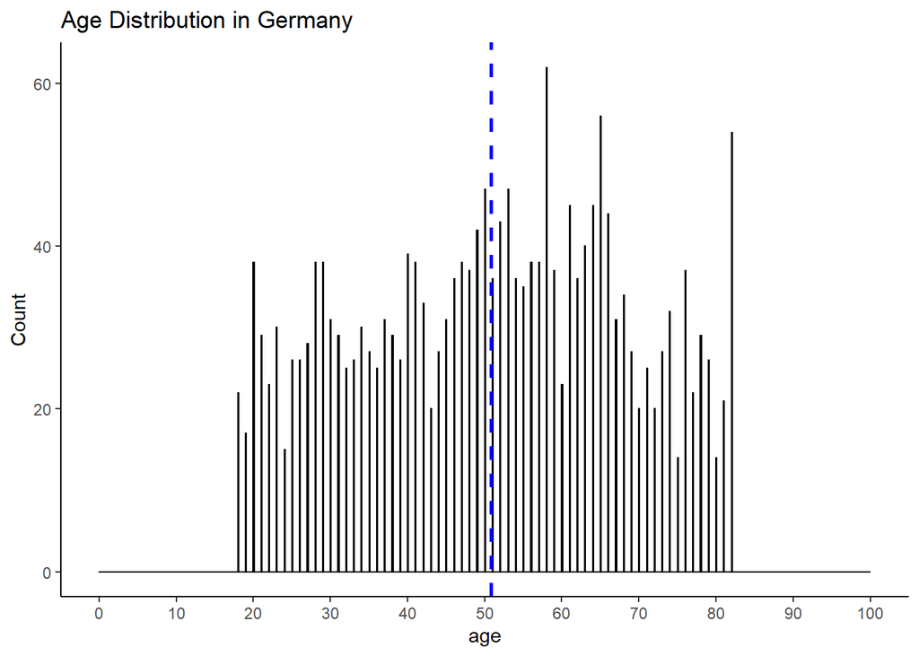

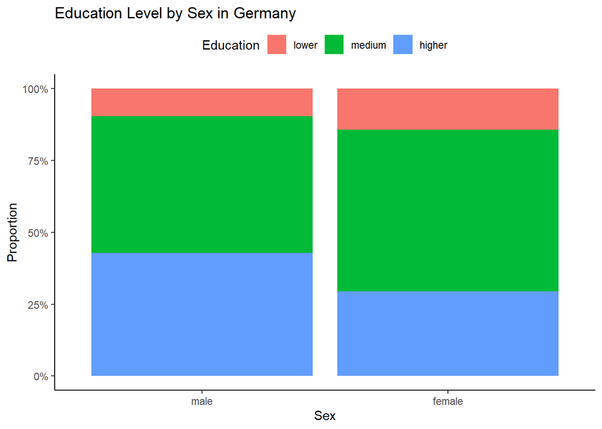

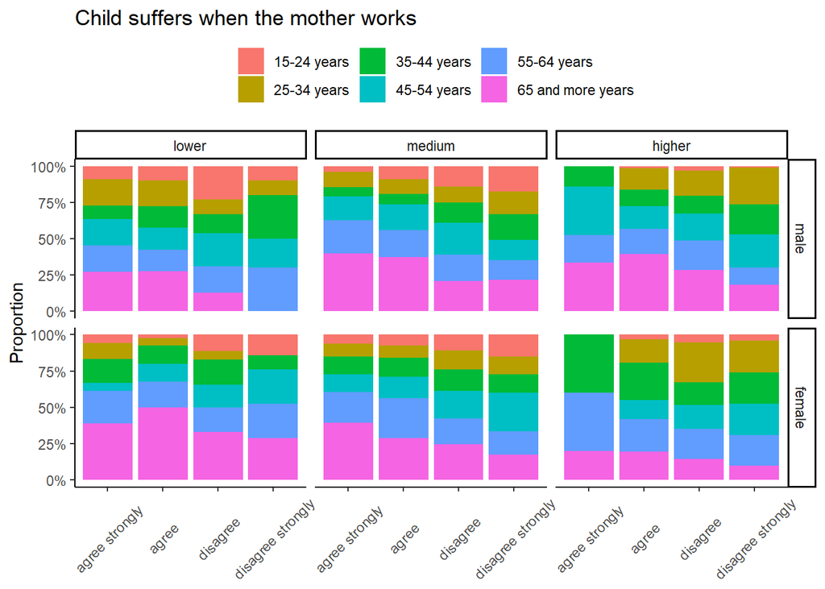

# Regression

Once the parameters are set in the Overview section, the formula used to calculate the regression is displayed. The coefficients of the regression are displayed and the predicted values can be evaluated with the residual plot.

```
## [1] "`Child suffers when the mother works` ~ Education + poly(age,2)"
```

```
## # A tibble: 4 x 5
##   term          estimate std.error statistic   p.value
##   <chr>            <dbl>     <dbl>     <dbl>     <dbl>
## 1 (Intercept)      2.32     0.0631     36.8  1.88e-228
## 2 Education        0.222    0.0271      8.19 4.40e- 16
## 3 poly(age, 2)1   -6.41     0.800      -8.01 1.89e- 15
## 4 poly(age, 2)2   -2.24     0.803      -2.79 5.34e-  3
```

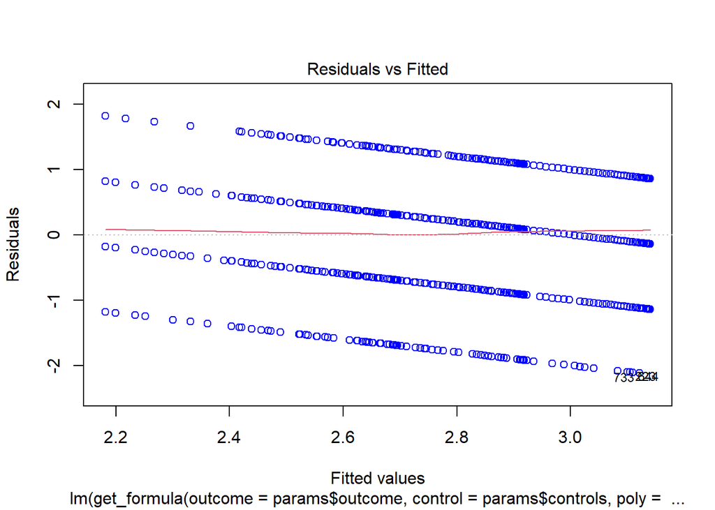